# R Markdown Homework

Jinyu Du

Completed on November 02 2021

# 1 Examples of all three ways to use R chunks using the mtcars data set

## 1.1 Display both the code and the output from running the code

The mtcars data set contains “fuel consumption and 10 aspects of automobile design and performance for 32 automobiles (1973–74 models)”. It is a data frame with 32 observations and 11 columns of numeric variables.

Let’s look at the first six rows of the data set.

```r
knitr::kable(head(mtcars[1:6,], "pipe"))
```

|  | mpg | cyl | disp | hp | drat | wt | qsec | vs | am | gear | carb |
| --- | --- | --- | --- | --- | --- | --- | --- | --- | --- | --- | --- |
| Mazda RX4 | 21.0 | 6 | 160 | 110 | 3.90 | 2.620 | 16.46 | 0 | 1 | 4 | 4 |
| Mazda RX4 Wag | 21.0 | 6 | 160 | 110 | 3.90 | 2.875 | 17.02 | 0 | 1 | 4 | 4 |
| Datsun 710 | 22.8 | 4 | 108 | 93 | 3.85 | 2.320 | 18.61 | 1 | 1 | 4 | 1 |
| Hornet 4 Drive | 21.4 | 6 | 258 | 110 | 3.08 | 3.215 | 19.44 | 1 | 0 | 3 | 1 |
| Hornet Sportabout | 18.7 | 8 | 360 | 175 | 3.15 | 3.440 | 17.02 | 0 | 0 | 3 | 2 |
| Valiant | 18.1 | 6 | 225 | 105 | 2.76 | 3.460 | 20.22 | 1 | 0 | 3 | 1 |

The table below describes the 11 numeric variables.

| Column number | Variable name | Variable description |
| --- | --- | --- |
| 1 | mpg | Miles/(US) gallon |
| 2 | cyl | Number of cylinders |
| 3 | disp | Displacement (cu.in.) |
| 4 | hp | Gross horsepower |
| 5 | drat | Rear axle ratio |
| 6 | wt | Weight (1000 lbs) |
| 7 | qsec | 1/4 mile time |
| 8 | vs | Engine (0 = V-shaped, 1 = straight) |
| 9 | am | Transmission (0 = automatic, 1 = manual) |
| 10 | gear | Number of forward gears |
| 11 | carb | Number of carburetors |

## 1.2 Display the output from running the code without displaying the code

I want to understand the distribution of the variable mpg by plotting a histogram.

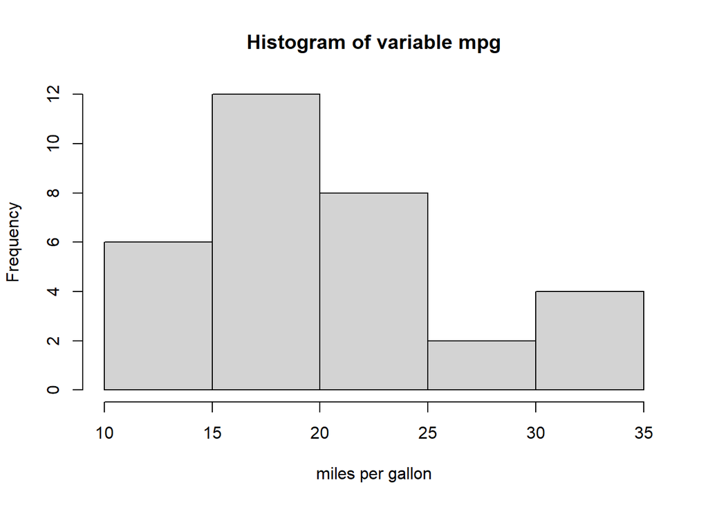

From the histogram, we see that the distribution of the variable mpg is somewhat right-skewed.

## 1.3 Display the code without actually running it

To know more about the mtcars data set, one can run the following code.

```
help(mtcars)
```

Running the `help(mtcars)` code will pull up the html help page for the mtcars data set.

# 2 A tutorial of simple linear regression

## 2.1 What is simple linear regression?

Linear regression is a fundamental but important statistical learning method. Simple linear regression builds a linear model that predicts a numerical response variable $Y$ using a single numerical predictor variable $X$. The underlying assumption is that there is an approximately linear relationship between X and Y. That is,

$$Y \simeq \beta_{0} + \beta_{1}X$$
In this model, $\beta_{0}$ and $\beta_{1}$ are two unknown parameters. When fitting a simple linear regression model on a data set, we essentially produce our best guesses for the true parameters $\beta_{0}$ and $\beta_{1}$. We denote the estimated parameters as $\hat\beta_{0}$ and $\hat\beta_{1}$. That is,
$$\hat{y} = \hat\beta_{0} + \hat\beta_{1}x$$
where $\hat{y}$ denotes a prediction of $Y$ at $X=x$ using the fitted simple linear regression model.

Consider a data set where X is the number of study hours per week of a student in a statistics class, and Y is his/her final grade for the class. For this data set, a simple linear regression model can be helpful. We can fit a model
$$grade \simeq \beta_{0} + \beta_{1}\times hours$$

## 2.2 Criteria for estimating the best parameters

When fitting a linear regression model, the natural question is what makes the best estimates for the parameters? The answer is that the best parameter estimates minimize the residual sum of squares (RSS).

The residual sum of squares (RSS) is defined as

$$RSS = e_{1}^2+e_{2}^2+\dots +e_{n}^2$$

where the residual $e_{n} = y_{n} - \hat\beta_{0} - \hat\beta_{1}x_{n}$, and $(x_{n}, y_{n})$ is the $n^{th}$ pair of data point in the data set.

Choosing parameter estimates that minimize the RSS is also called the least-squares approach. For this reason, the parameter estimates are also referred to as the least-squares coefficient/parameter estimates.

Mathematically, we can derive that the least-squares coefficient/parameter estimates are
$$\hat\beta_{1} = \frac{\sum_{i=1}^{n}(x_i-\bar{x})(y_i-\bar{y})}{\sum_{i=1}^{n}(x_i-\bar{x})^2}$$
$$\hat\beta_{0} = \bar{y} - \hat\beta_{1}\bar{x}$$
where $\bar{y}=\frac{1}{n}\sum_{i=1}^{n}y_i$ and $\bar{x}=\frac{1}{n}\sum_{i=1}^{n}x_i$.

## 2.3 Simple linear regression model in R

### 2.3.1 Fitting a simple linear regression model in R

Suppose we have a simple data set with two variables: X is the number of study hours per week of a student in a statistics class, and Y is his/her final grade for the class.

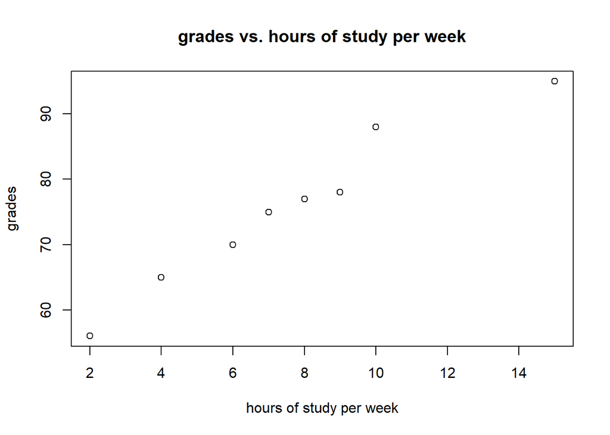

```r
x <- c(2, 4, 6, 7, 9, 8, 10, 15)
y <- c(56, 65, 70, 75, 78, 77, 88, 95)
plot(x,y,
     main="grades vs. hours of study per week",
     xlab="hours of study per week",
     ylab="grades")
```

The plot shows that a simple linear regression is a proper model for the data because the scatter plot presents a strong linear relationship between hours per week and grades.

Next, we will fit a simple linear regression model for the data.

```r
slr.fit = lm(y~x)
slr.fit
```

```
##
## Call:
## lm(formula = y ~ x)
##
## Coefficients:
## (Intercept)            x
##      52.287        3.044
```

Now, let’s add the linear regression line to the plot.

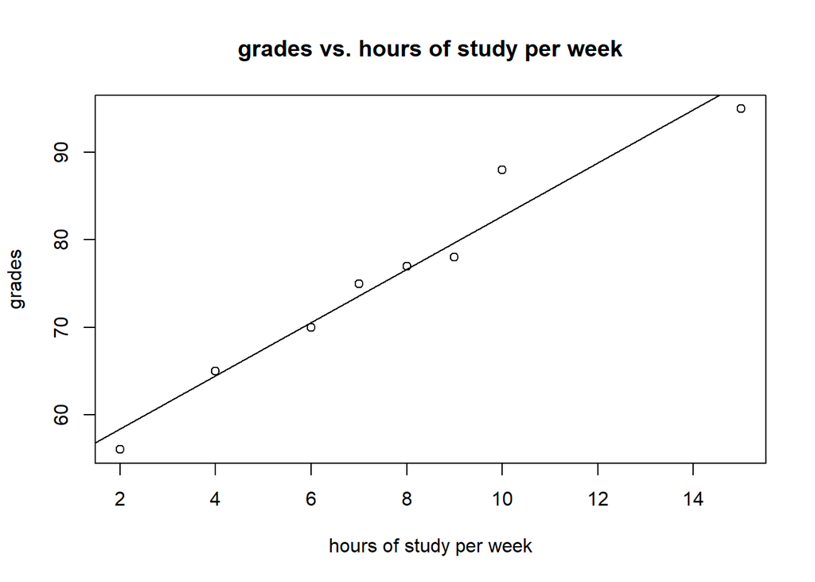

```r
plot(x,y,
     main="grades vs. hours of study per week",
     xlab="hours of study per week",
     ylab="grades")
abline(slr.fit)
```

```r
summary(slr.fit)
```

```
##
## Call:
## lm(formula = y ~ x)
##
## Residuals:
##     Min      1Q  Median      3Q     Max
## -2.9522 -1.8584 -0.0973  0.7526  5.2696
##
## Coefficients:
##             Estimate Std. Error t value Pr(>|t|)
## (Intercept)  52.2867     2.2795   22.94 4.50e-07 ***
## x             3.0444     0.2689   11.32 2.84e-05 ***
## ---
## Signif. codes:  0 '***' 0.001 '**' 0.01 '*' 0.05 '.' 0.1 ' ' 1
##
## Residual standard error: 2.818 on 6 degrees of freedom
## Multiple R-squared:  0.9553, Adjusted R-squared:  0.9478
## F-statistic: 128.2 on 1 and 6 DF,  p-value: 2.841e-05
```

```r
betas = coef(slr.fit)
```

The output from R shows that the slope of the regression is 3.0443686, and the intercept of the regression is 52.2866894. The multiple R-squared is 0.9553, indicating a very strong linear relationship between hours of study per week and grades.

### 2.3.2 Calculating 95% confidence intervals for the parameter estimates

```r
confint(slr.fit)
```

```
##                 2.5 %    97.5 %
## (Intercept) 46.709013 57.864366
## x            2.386462  3.702275
```

The output shows the 95% confidence interval for the intercept is $(46.709013, 57.864366)$. The 95% confidence interval for the slope is $(2.386462, 3.702275)$.

### 2.3.3 Making predictions

```r
predict(slr.fit, data.frame(x=c(3, 12, 13)))
```

```
##        1        2        3
## 61.41980 88.81911 91.86348
```

Here is how to interpret the output: the results show that when $x = 3$, the predicted value $\hat{y}=61.42$, when $x = 12$, the predicted value $\hat{y}=88.82$, and when $x = 13$, the predicted value $\hat{y}=91.86$.

### 2.3.4 Regression diagnostics using the residual plot

The code below plots the residual plot.

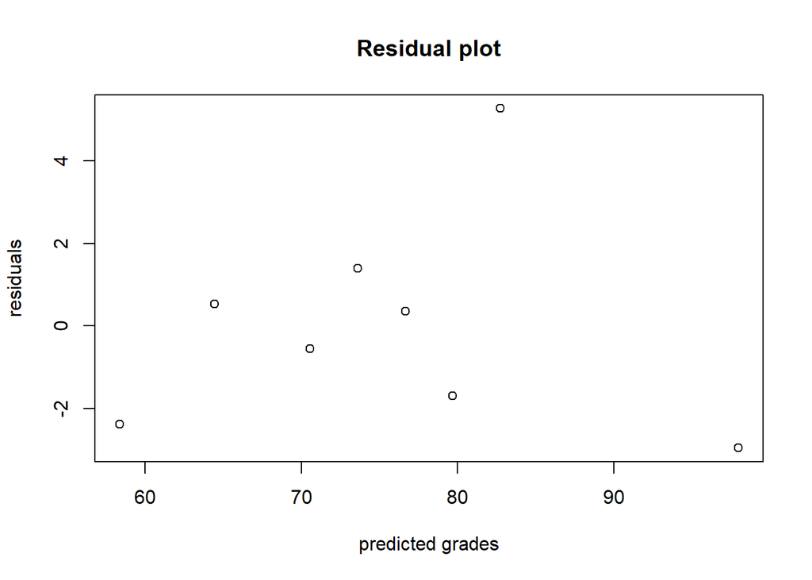

```r
plot(predict(slr.fit), residuals(slr.fit),
     main="Residual plot",
     xlab="predicted grades",
     ylab="residuals")
```

The basic assumption for linear regression is that residuals follow independent and identical normal distributions. The assumption may be abstract to understand. But the intuitive understanding is simple, which says the residual plot of the regression model should have residuals randomly scattered with no apparent pattern if the assumption for fitting linear regression models is met.

The above residual plot does look random with no apparent pattern. Thus the basic assumption for the linear regression is satisfied, and the model is a good fit.

# 3 Let’s do something new

## 3.1 Insert an html widgets of Google map into R Markdown

### 3.1.1 Location of the Heroy Science Hall at SMU

Below is a dynamic map that shows the location of the Statistical Science Department at Southern Methodist University (SMU).

[interactive chart not shown]

### 3.1.2 Steps for insert an html widgets of Google map into R Markdown

You may wonder how to insert an html widget of Google Maps into R Markdown. Here is the answer in simple steps:

- Think of a location you like. Then Find the latitude and longitude of the place. This website [latlong.net](https://www.latlong.net/) is a very helpful latitude and longitude finder.
- Use the code block below as a template. Replace the latitude and longitude with the exact latitude and longitude for the location of your interest.
- Before you run it, make sure you put three backticks at the beginning and the end of the code chunks!
- Run the code in R, and you should see the correct map!

```
{r out.width='80%', echo=FALSE}
library(leaflet)
leaflet() %>% addTiles() %>%
  setView(longitude, latitude, zoom = 18) %>%
  addPopups(
    longitude, latitude,
    'Here is the <b>Department of Statistical Science</b>, SMU')
```

[figure not shown]

Thank you!

## 3.2 Homework completion checklist:

Create an R Markdown document that includes the following:  
1. A floating table of contents  
2. At least 3 sections with different levels of headers  
3. A bulleted list  
4. Examples of all three ways to use R chunks using the mtcars data set.  
5. A table with at least 3 columns and 4 rows  
6. An image that is centered  
7. A hyperlink that is embedded  
8. At least TWO things we did NOT talk about.

What are new:  
(1) Use kable to pipe in the data as a table.  
(2) Insert a map using the html widget  
(3) Use a checklist